# 2nd week assignment

# Reproducible Analysis - 2nd week assessment

It is now possible to collect a large amount of data about personal movement using activity monitoring devices such as a Fitbit, Nike Fuelband, or Jawbone Up. These type of devices are part of the “quantified self” movement – a group of enthusiasts who take measurements about themselves regularly to improve their health, to find patterns in their behavior, or because they are tech geeks. But these data remain under-utilized both because the raw data are hard to obtain and there is a lack of statistical methods and software for processing and interpreting the data.

This assignment makes use of data from a personal activity monitoring device. This device collects data at 5 minute intervals through out the day. The data consists of two months of data from an anonymous individual collected during the months of October and November, 2012 and include the number of steps taken in 5 minute intervals each day.

##1) Loading and preprocessing the data Show any code that is needed to load the data (i.e. read.csv())and process/transform the data (if necessary) into a format suitable for your analysis

```r
activitydata <- read.csv("repdata_data_activity/activity.csv")
summary(activitydata)
```

```
##      steps            date              interval
##  Min.   :  0.00   Length:17568       Min.   :   0.0
##  1st Qu.:  0.00   Class :character   1st Qu.: 588.8
##  Median :  0.00   Mode  :character   Median :1177.5
##  Mean   : 37.38                      Mean   :1177.5
##  3rd Qu.: 12.00                      3rd Qu.:1766.2
##  Max.   :806.00                      Max.   :2355.0
##  NA's   :2304
```

## What is mean total number of steps taken per day?

For this part of the assignment, you can ignore the missing values in the dataset.

### Make a histogram of the total number of steps taken each day

The first step here is to remove the rows with NA values, and aggregate the number of steps by date (summing all steps taken per day)

```r
activitydata_complete <- activitydata[complete.cases(activitydata),]
steps_aggregate_date<-aggregate(activitydata_complete$steps, by=list(activitydata_complete$date), FUN=sum)
```

We can then plot the total steps walked each day thanks to a barplot

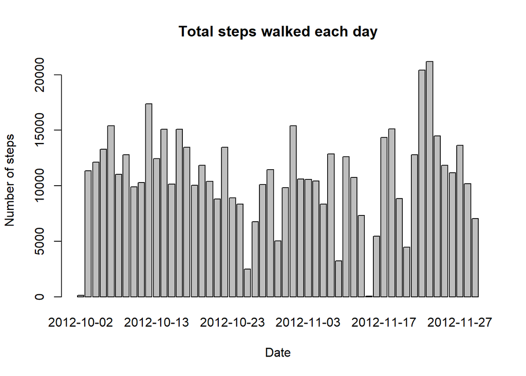

```r
barplot(steps_aggregate_date$x, names.arg=steps_aggregate_date$Group.1, main = "Total steps walked each day", xlab = "Date", ylab = "Number of steps")
```

### Calculate and report the mean and median total number of steps taken per day

```r
summary(steps_aggregate_date$x)
```

```
##    Min. 1st Qu.  Median    Mean 3rd Qu.    Max.
##      41    8841   10765   10766   13294   21194
```

## What is the average daily activity pattern?

### Make a time series plot (i.e. type = “l”) of the 5-minute interval (x-axis) and the average number of steps taken, averaged across all days (y-axis)

First we must calculate the average number of steps for each interval across all days

```r
steps_aggregate_inter<-aggregate(activitydata_complete$steps, by=list(activitydata_complete$interval), FUN=mean)
```

We can then plot the results :

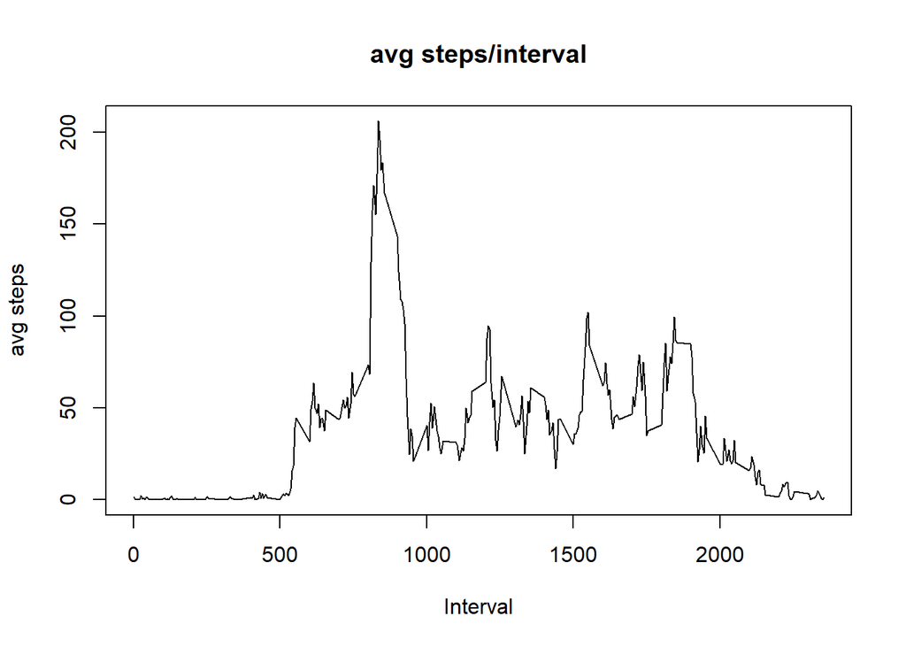

```r
plot(steps_aggregate_inter$Group.1,steps_aggregate_inter$x, type = "l", xlab = "Interval", ylab = "avg steps", main = "avg steps/interval")
```

### Which 5-minute interval, on average across all the days in the dataset, contains the maximum number of steps?

```r
steps_aggregate_inter[match(max(steps_aggregate_inter$x),steps_aggregate_inter$x),1]
```

```
## [1] 835
```

## Imputing missing values

Note that there are a number of days/intervals where there are missing values (coded as NA). The presence of missing days may introduce bias into some calculations or summaries of the data.

### Calculate and report the total number of missing values in the dataset (i.e. the total number of rows with NAs)

```r
sum(is.na(activitydata$steps))
```

```
## [1] 2304
```

### Devise a strategy for filling in all of the missing values in the dataset.

The strategy does not need to be sophisticated. For example, you could use the mean/median for that day, or the mean for that 5-minute interval, etc. Create a new dataset that is equal to the original dataset but with the missing data filled in.

Solution : Since we are measuring steps taken by people, it seems more logical to take into account the daily walking pattern rather than the daily avg number of steps, we’ll therefore fill in the blanks with the mean for that 5 min interval

```r
activitydata_fill <- activitydata

for (i in 1:length(activitydata$steps)){
  if(is.na(activitydata_fill[i,"steps"]))
    activitydata_fill[i,"steps"]<-steps_aggregate_inter[match(activitydata_fill[i,"interval"],steps_aggregate_inter$Group.1),"x"]}
```

### Make a histogram of the total number of steps taken each day and Calculate and report the mean and median total number of steps taken per day.

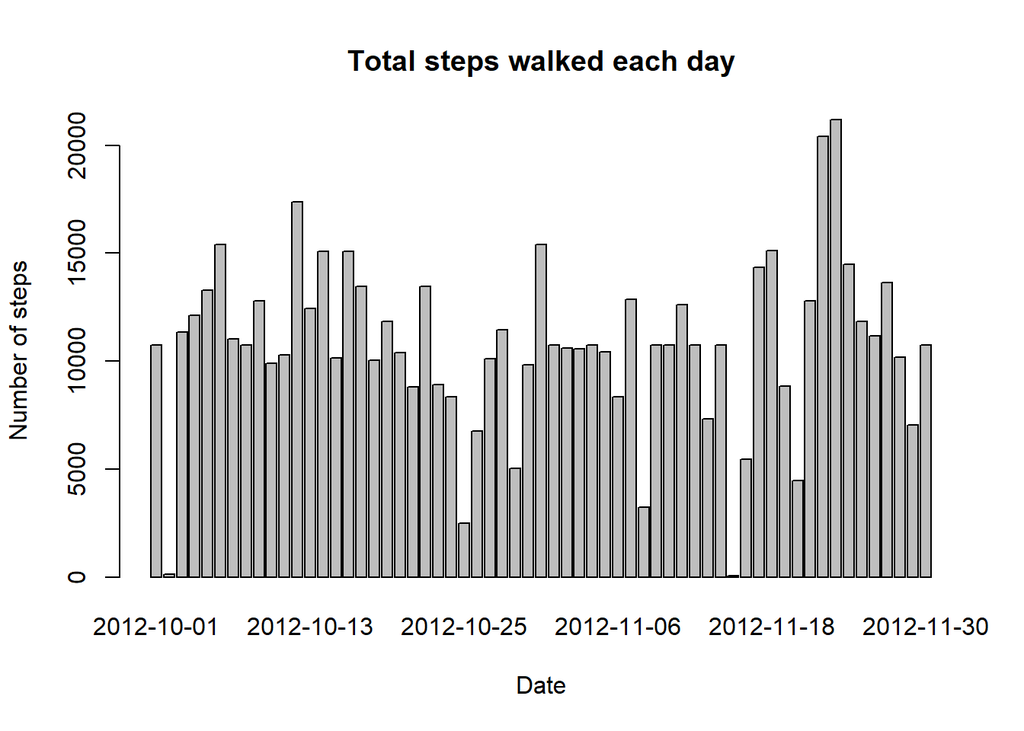

```r
steps_aggregate_fill_date<-aggregate(activitydata_fill$steps, by=list(activitydata_fill$date), FUN=sum)

barplot(steps_aggregate_fill_date$x, names.arg=steps_aggregate_fill_date$Group.1, main = "Total steps walked each day", xlab = "Date", ylab = "Number of steps")
```

Original Data summary

```r
summary(steps_aggregate_date$x)
```

```
##    Min. 1st Qu.  Median    Mean 3rd Qu.    Max.
##      41    8841   10765   10766   13294   21194
```

Filled data summary

```r
summary(steps_aggregate_fill_date$x)
```

```
##    Min. 1st Qu.  Median    Mean 3rd Qu.    Max.
##      41    9819   10766   10766   12811   21194
```

### Do these values differ from the estimates from the first part of the assignment? What is the impact of imputing missing data on the estimates of the total daily number of steps?

Since we used the average steps by interval, the aggregated medians and means are the same, however the new values change the 1st and 3rd quartile

## Are there differences in activity patterns between weekdays and weekends?

For this part the weekdays() function may be of some help here. Use the dataset with the filled-in missing values for this part.

Create a new factor variable in the dataset with two levels – “weekday” and “weekend” indicating whether a given date is a weekday or weekend day.

First let’s add a correspondence table:

```r
corr_table <- cbind(dayname=c("Monday","Tuesday","Wednesday","Thursday","Friday","Saturday","Sunday"),daytype=c("Weekday","Weekday","Weekday","Weekday","Weekday","Weekend","Weekend"))

activitydata_day <- activitydata_fill
activitydata_day$day <- factor( corr_table[ match( weekdays( as.POSIXct(activitydata_day$date)),corr_table),"daytype"],levels=c("Weekday","Weekend"))
head(activitydata_day)
```

```
##       steps       date interval     day
## 1 1.7169811 2012-10-01        0 Weekday
## 2 0.3396226 2012-10-01        5 Weekday
## 3 0.1320755 2012-10-01       10 Weekday
## 4 0.1509434 2012-10-01       15 Weekday
## 5 0.0754717 2012-10-01       20 Weekday
## 6 2.0943396 2012-10-01       25 Weekday
```

### Make a panel plot containing a time series plot (i.e. type = “l”) of the 5-minute interval (x-axis) and the average number of steps taken, averaged across all weekday days or weekend days (y-axis).

Let’s separate the weekday and weekend data for each plot

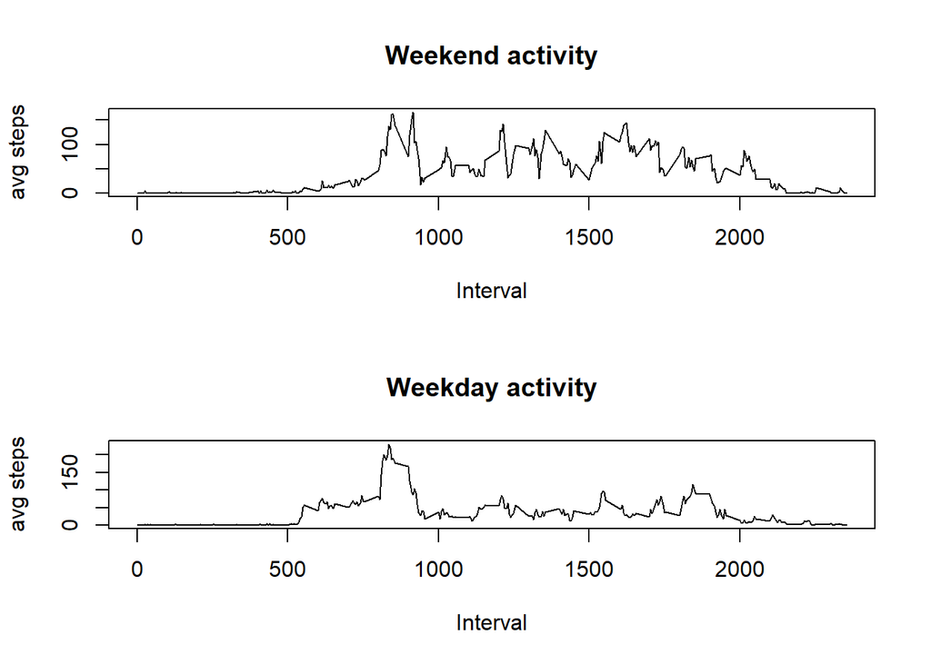

```r
week_data <- aggregate(activitydata_day$steps,by=list(activitydata_day$interval,activitydata_day$day), FUN=mean)

par(mfrow=c(2,1))
plot(week_data[week_data$Group.2=="Weekend","Group.1"],week_data[week_data$Group.2=="Weekend","x"], type = "l", xlab = "Interval", ylab = "avg steps", main = "Weekend activity")
plot(week_data[week_data$Group.2=="Weekday","Group.1"],week_data[week_data$Group.2=="Weekday","x"], type = "l", xlab = "Interval", ylab = "avg steps", main = "Weekday activity")
```